# Exploring Factors Associated with Student Stress

### A Behavioral Data Analysis Using Student Survey Responses

## Objective

This project explores factors that may be associated with stress among students, including optimism, sleep duration, social support, and work-life balance.

The analysis was conducted using survey responses collected from students and analyzed using Python, pandas, and Jupyter Notebook.

## Dataset Overview

The dataset consists of 20 student survey responses covering topics related to optimism, stress, sleep habits, social support, and lifestyle behaviors.

The survey was designed to explore possible relationships between emotional, social, and behavioral factors and student stress levels.

```python
import pandas as pd
```

```python
df = pd.read_csv("Optimism and Stress Level Study.csv")
```

```python
df.head()
```

|  | Timestamp | What is your current academic level? | What is your age range? | On a scale of 1 to 5, how optimistic do you generally feel about your future academic and career prospects? (1=Not at all optimistic, 5=Extremely optimistic) | I usually expect good things to happen in my life. | I remain hopeful even during difficult situations. | I believe I can overcome most challenges. | I try to focus on positive aspects of situations. | I feel confident about my future. | I recover quickly after setbacks or disappointments. | ... | How often have you felt overwhelmed or unable to cope in the past month? | How often do you exercise or participate in physical activity weekly? | Approximately how many hours of screen time do you have daily (excluding academic work)? | How often do you take breaks or engage in relaxing activities during stressful periods? | How would you describe your overall work-life balance as a student? | How supported do you feel by friends, classmates, or family during stressful times? | During stressful periods, how often do you maintain a positive mindset? | Which of the following factors contribute most significantly to your stress? (Select all that apply) | How well do you manage stress when it arises? | @ |
| --- | --- | --- | --- | --- | --- | --- | --- | --- | --- | --- | --- | --- | --- | --- | --- | --- | --- | --- | --- | --- | --- |
| 0 | 5/13/2026 6:42:23 | Undergraduate (Junior/Senior) | 22 - 25 | 3 | Agree | Agree | Neutral | Agree | Disagree | Disagree | ... | Sometimes | Sometimes | More than 7 hours | Sometimes | Very Poor | 3 | Sometimes | Academic workload/Exams, Financial concerns, S... | 2 | NaN |
| 1 | 5/13/2026 6:57:33 | Undergraduate (Freshman/Sophomore) | 22 - 25 | 4 | Agree | Neutral | Strongly Agree | Strongly Disagree | Neutral | Disagree | ... | Very Often | Occasionally | More than 7 hours | Sometimes | Neutral | 5 | Rarely | Academic workload/Exams, Financial concerns, S... | 1 | NaN |
| 2 | 5/13/2026 7:42:07 | Undergraduate (Junior/Senior) | 18 - 21 | 4 | Agree | Agree | Agree | Agree | Strongly Agree | Agree | ... | Fairly Often | Often | 5–7 hours | Sometimes | Good | 3 | Sometimes | Academic workload/Exams, Financial concerns, F... | 4 | NaN |
| 3 | 5/13/2026 8:12:12 | Graduate/Post-Graduate | 31 or above | 4 | Agree | Strongly Agree | Strongly Agree | Strongly Agree | Agree | Agree | ... | Fairly Often | Occasionally | 5–7 hours | Sometimes | Very Poor | 5 | Always | Academic workload/Exams, Future career uncerta... | 5 | NaN |
| 4 | 5/13/2026 8:52:02 | Undergraduate (Junior/Senior) | 18 - 21 | 2 | Disagree | Disagree | Disagree | Strongly Disagree | Strongly Disagree | Strongly Disagree | ... | Very Often | Occasionally | 2–4 hours | Sometimes | Very Poor | 4 | Rarely | Academic workload/Exams, Future career uncerta... | 1 | NaN |

5 rows × 28 columns

```python
df.info()
```

```
<class 'pandas.core.frame.DataFrame'>
RangeIndex: 20 entries, 0 to 19
Data columns (total 28 columns):
 #   Column                                                                                                                                                         Non-Null Count  Dtype
---  ------                                                                                                                                                         --------------  -----
 0   Timestamp                                                                                                                                                      20 non-null     object
 1   What is your current academic level?                                                                                                                           20 non-null     object
 2   What is your age range?                                                                                                                                        20 non-null     object
 3   On a scale of 1 to 5, how optimistic do you generally feel about your future academic and career prospects? (1=Not at all optimistic, 5=Extremely optimistic)  20 non-null     int64
 4     I usually expect good things to happen in my life.                                                                                                           20 non-null     object
 5   I remain hopeful even during difficult situations.                                                                                                             20 non-null     object
 6   I believe I can overcome most challenges.                                                                                                                      20 non-null     object
 7   I try to focus on positive aspects of situations.                                                                                                              20 non-null     object
 8   I feel confident about my future.                                                                                                                              20 non-null     object
 9   I recover quickly after setbacks or disappointments.                                                                                                           20 non-null     object
```

[output cut: 20 more lines]

## Data Cleaning

The dataset was cleaned by:

- Removing empty or unnecessary columns
- Renaming long column titles for easier analysis
- Checking for missing values and formatting consistency

```python
df= df.drop(columns=["@"])
```

```python
df.head()
```

|  | Timestamp | What is your current academic level? | What is your age range? | On a scale of 1 to 5, how optimistic do you generally feel about your future academic and career prospects? (1=Not at all optimistic, 5=Extremely optimistic) | I usually expect good things to happen in my life. | I remain hopeful even during difficult situations. | I believe I can overcome most challenges. | I try to focus on positive aspects of situations. | I feel confident about my future. | I recover quickly after setbacks or disappointments. | ... | On average, how many hours do you sleep each night? | How often have you felt overwhelmed or unable to cope in the past month? | How often do you exercise or participate in physical activity weekly? | Approximately how many hours of screen time do you have daily (excluding academic work)? | How often do you take breaks or engage in relaxing activities during stressful periods? | How would you describe your overall work-life balance as a student? | How supported do you feel by friends, classmates, or family during stressful times? | During stressful periods, how often do you maintain a positive mindset? | Which of the following factors contribute most significantly to your stress? (Select all that apply) | How well do you manage stress when it arises? |
| --- | --- | --- | --- | --- | --- | --- | --- | --- | --- | --- | --- | --- | --- | --- | --- | --- | --- | --- | --- | --- | --- |
| 0 | 5/13/2026 6:42:23 | Undergraduate (Junior/Senior) | 22 - 25 | 3 | Agree | Agree | Neutral | Agree | Disagree | Disagree | ... | Less than 5 hours | Sometimes | Sometimes | More than 7 hours | Sometimes | Very Poor | 3 | Sometimes | Academic workload/Exams, Financial concerns, S... | 2 |
| 1 | 5/13/2026 6:57:33 | Undergraduate (Freshman/Sophomore) | 22 - 25 | 4 | Agree | Neutral | Strongly Agree | Strongly Disagree | Neutral | Disagree | ... | Less than 5 hours | Very Often | Occasionally | More than 7 hours | Sometimes | Neutral | 5 | Rarely | Academic workload/Exams, Financial concerns, S... | 1 |
| 2 | 5/13/2026 7:42:07 | Undergraduate (Junior/Senior) | 18 - 21 | 4 | Agree | Agree | Agree | Agree | Strongly Agree | Agree | ... | 7–8 hours | Fairly Often | Often | 5–7 hours | Sometimes | Good | 3 | Sometimes | Academic workload/Exams, Financial concerns, F... | 4 |
| 3 | 5/13/2026 8:12:12 | Graduate/Post-Graduate | 31 or above | 4 | Agree | Strongly Agree | Strongly Agree | Strongly Agree | Agree | Agree | ... | 5–6 hours | Fairly Often | Occasionally | 5–7 hours | Sometimes | Very Poor | 5 | Always | Academic workload/Exams, Future career uncerta... | 5 |
| 4 | 5/13/2026 8:52:02 | Undergraduate (Junior/Senior) | 18 - 21 | 2 | Disagree | Disagree | Disagree | Strongly Disagree | Strongly Disagree | Strongly Disagree | ... | Less than 5 hours | Very Often | Occasionally | 2–4 hours | Sometimes | Very Poor | 4 | Rarely | Academic workload/Exams, Future career uncerta... | 1 |

5 rows × 27 columns

# Optimism vs Stress

```python
df = df.rename(columns={
    "On a scale of 1 to 5, how optimistic do you generally feel about your future academic and career prospects? (1=Not at all optimistic, 5=Extremely optimistic)": "optimism_score",

    "On a scale of 1 to 5, how would you rate your current overall stress level as a student? (1=No stress, 5=Severe stress)": "stress_score"
})
```

```python
df[["optimism_score", "stress_score"]].head()
```

|  | optimism_score | stress_score |
| --- | --- | --- |
| 0 | 3 | 5 |
| 1 | 4 | 4 |
| 2 | 4 | 4 |
| 3 | 4 | 2 |
| 4 | 2 | 5 |

```python
df[["optimism_score", "stress_score"]].corr()
```

|  | optimism_score | stress_score |
| --- | --- | --- |
| optimism_score | 1.000000 | 0.026592 |
| stress_score | 0.026592 | 1.000000 |

### Insight

The analysis showed little to no direct correlation between optimism and overall stress level among the surveyed students. This suggests that academic stress may be influenced by multiple factors beyond general optimism alone.

```python
import matplotlib.pyplot as plt
```

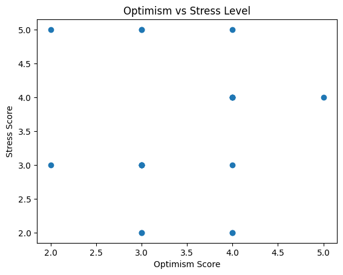

```python
plt.scatter(df["optimism_score"], df["stress_score"])

plt.title("Optimism vs Stress Level")
plt.xlabel("Optimism Score")
plt.ylabel("Stress Score")

plt.show()
```

## Insight

The scatter plot shows little visible relationship between optimism scores and stress levels among the surveyed students. While some optimistic students reported lower stress, others still experienced moderate to high stress levels.

This suggests that academic stress may be influenced by multiple factors beyond optimism alone.

```python
df["stress_score"].value_counts()
```

```
stress_score
3    7
4    5
5    4
2    4
Name: count, dtype: int64
```

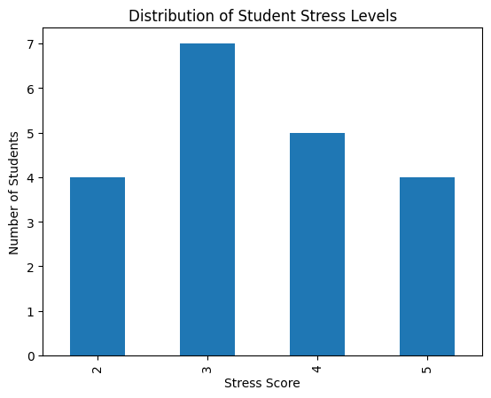

```python
df["stress_score"].value_counts().sort_index().plot(kind="bar")

plt.title("Distribution of Student Stress Levels")
plt.xlabel("Stress Score")
plt.ylabel("Number of Students")

plt.show()
```

## Insight

The distribution shows that most students reported moderate to high stress levels, with stress scores of 3 and 4 being the most common. This suggests that academic stress is a common experience among the surveyed students.

```python
df.columns
```

```
Index(['Timestamp', 'What is your current academic level?',
       'What is your age range?', 'optimism_score',
       '  I usually expect good things to happen in my life.  ',
       'I remain hopeful even during difficult situations. ',
       'I believe I can overcome most challenges. ',
       'I try to focus on positive aspects of situations. ',
       'I feel confident about my future. ',
       'I recover quickly after setbacks or disappointments. ',
       'I often feel overwhelmed by academic responsibilities. ',
       'I frequently feel stressed because of school or university work. ',
       'I struggle to relax due to academic pressure. ',
       'I worry a lot about my academic performance. ',
       'I feel mentally exhausted during most weeks. ',
       'Academic stress negatively affects my mood. ', 'stress_score',
       '  On average, how many hours do you sleep each night?  ',
       'How often have you felt overwhelmed or unable to cope in the past month?',
       'How often do you exercise or participate in physical activity weekly?  ',
       '   Approximately how many hours of screen time do you have daily (excluding academic work)?  ',
       ' How often do you take breaks or engage in relaxing activities during stressful periods?  ',
       'How would you describe your overall work-life balance as a student?  ',
       '  How supported do you feel by friends, classmates, or family during stressful times?  ',
       'During stressful periods, how often do you maintain a positive mindset?  ',
       'Which of the following factors contribute most significantly to your stress? (Select all that apply)',
       'How well do you manage stress when it arises?'],
      dtype='object')
```

# Sleep vs Stress

```python
df = df.rename(columns={
    "  On average, how many hours do you sleep each night?  ": "sleep_hours"
})
```

```python
df["sleep_hours"].value_counts()
```

```
sleep_hours
5–6 hours            10
7–8 hours             7
Less than 5 hours     3
Name: count, dtype: int64
```

```python
df.groupby("sleep_hours")["stress_score"].mean()
```

```
sleep_hours
5–6 hours            3.400000
7–8 hours            3.000000
Less than 5 hours    4.666667
Name: stress_score, dtype: float64
```

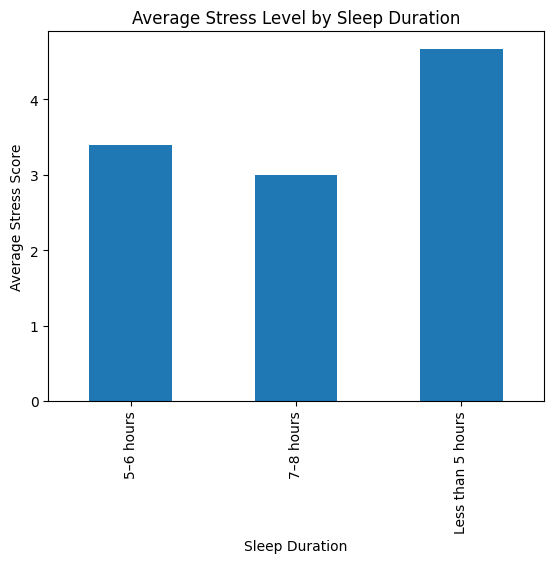

```python
df.groupby("sleep_hours")["stress_score"].mean().plot(kind="bar")

plt.title("Average Stress Level by Sleep Duration")
plt.xlabel("Sleep Duration")
plt.ylabel("Average Stress Score")

plt.show()
```

## Insight

Students who slept less than 5 hours per night reported the highest average stress levels. In contrast, students who slept 7–8 hours showed lower average stress levels.

This suggests that sleep duration may play an important role in student stress and well-being.

# Social Support vs Stress

```python
df = df.rename(columns={
    "  How supported do you feel by friends, classmates, or family during stressful times?  ": "support_level"
})
```

```python
df["support_level"].value_counts()
```

```
support_level
4    7
3    6
5    4
2    2
1    1
Name: count, dtype: int64
```

```python
df.groupby("support_level")["stress_score"].mean()
```

```
support_level
1    5.000000
2    4.000000
3    3.500000
4    3.142857
5    3.250000
Name: stress_score, dtype: float64
```

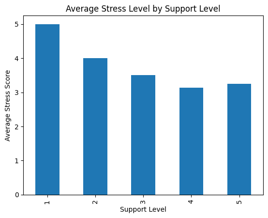

```python
df.groupby("support_level")["stress_score"].mean().plot(kind="bar")

plt.title("Average Stress Level by Support Level")
plt.xlabel("Support Level")
plt.ylabel("Average Stress Score")

plt.show()
```

## Insight

Students who reported lower levels of emotional or social support tended to experience higher stress levels. Participants with the lowest support levels reported the highest average stress scores.

This suggests that social support may play an important role in helping students manage academic stress.

# Work-Life Balance vs Stress

```python
df = df.rename(columns={
    "How would you describe your overall work-life balance as a student?  ": "work_life_balance"
})
```

```python
df["work_life_balance"].value_counts()
```

```
work_life_balance
Neutral      9
Very Poor    5
Good         5
Poor         1
Name: count, dtype: int64
```

```python
df.groupby("work_life_balance")["stress_score"].mean()
```

```
work_life_balance
Good         3.400000
Neutral      3.222222
Poor         3.000000
Very Poor    4.000000
Name: stress_score, dtype: float64
```

## Insight

Students reporting a very poor work-life balance showed higher average stress levels. However, the relationship between work-life balance and stress was less consistent across the other categories.

This may suggest that extreme imbalance is associated with stress, while moderate differences are less clear within the current sample.

# Comparative Analysis of Stress Factors

```python
summary_data = {
    "Factor": [
        "Optimism",
        "Sleep Duration",
        "Social Support",
        "Work-Life Balance"
    ],

    "Observed Relationship with Stress": [
        "Weak",
        "Strong",
        "Moderate to Strong",
        "Mixed"
    ],

    "Key Observation": [
        "Little direct correlation observed",
        "Lower sleep was associated with higher stress",
        "Lower support levels showed higher stress",
        "Only very poor balance showed noticeably higher stress"
    ]
}

summary_df = pd.DataFrame(summary_data)

summary_df
```

|  | Factor | Observed Relationship with Stress | Key Observation |
| --- | --- | --- | --- |
| 0 | Optimism | Weak | Little direct correlation observed |
| 1 | Sleep Duration | Strong | Lower sleep was associated with higher stress |
| 2 | Social Support | Moderate to Strong | Lower support levels showed higher stress |
| 3 | Work-Life Balance | Mixed | Only very poor balance showed noticeably highe... |

## Comparative Insight

Among the explored variables, sleep duration and social support appeared to show stronger relationships with student stress levels compared to optimism and work-life balance.

Students who slept less and reported lower support levels generally experienced higher stress scores. In contrast, optimism showed little direct correlation with stress within the current sample.

# Conclusion

This analysis explored several factors potentially associated with student stress levels.

Among the analyzed variables, sleep duration and social support appeared to show stronger relationships with stress levels. Students who slept less and reported lower support levels generally experienced higher stress scores.

In contrast, optimism showed little direct correlation with stress within this sample, suggesting that student stress may be influenced by multiple interconnected factors.

This project demonstrates the use of survey-based exploratory data analysis using Python, pandas, and data visualization techniques.

# Reflection

This project improved my understanding of exploratory data analysis, survey-based research, data visualization, and interpreting behavioral data using Python and Jupyter Notebook.